# Cwong Assign7

Calvin Wong

3/15/2019

1. Let X1, X2, . . . , Xn be n mutually independent random variables, each of which is uniformly distributed on the integers from 1 to k. Let Y denote the minimum of the Xi’s. Find the distribution of Y.

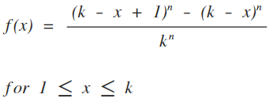

2. Your organization owns a copier (future lawyers, etc.) or MRI (future doctors). This machine has a manufacturer’s expected lifetime of 10 years. This means that we expect one failure every ten years. (Include the probability statements and R Code for each part.).
1. What is the probability that the machine will fail after 8 years?. Provide also the expected value and standard deviation. Model as a geometric. (Hint: the probability is equivalent to not failing during the first 8 years..)

Using this formula for geometric, f(x) = P(X=x) = (1−p)^x−1 * p

The probability that the machine will fail after 8 years can be calculated using pgeom function. Expected value is 1/p. And, to calculate SD we can use √(1−p)/p2

```r
a <- pgeom(8, 0.1, lower.tail = F)
a
```

```
## [1] 0.3874205
```

```r
a_expected <- 1/(1/10)
a_expected
```

```
## [1] 10
```

```r
a_sd <- sqrt(9/10/((1/10)^2))
a_sd
```

```
## [1] 9.486833
```

2. What is the probability that the machine will fail after 8 years?. Provide also the expected value and standard deviation. Model as an exponential.

Failure after 8 years: 1 - P(X <= 8).

```r
b <- 1 - pexp(8,0.1)
b
```

```
## [1] 0.449329
```

```r
b_expected <- 1/(1/10)
b_expected
```

```
## [1] 10
```

```r
b_sd <- sqrt((1/10)^-2)
b_sd
```

```
## [1] 10
```

3. What is the probability that the machine will fail after 8 years?. Provide also the expected value and standard deviation. Model as a binomial. (Hint: 0 success in 8 years)

X ~ B(8, 0.1) P(X = 0), to calculate standard deviation we can use √np∗(1−p)

```r
c = dbinom(0, 8, 0.1)
c
```

```
## [1] 0.4304672
```

```r
c_expected <- 8 * 0.1
c_expected
```

```
## [1] 0.8
```

```r
c_sd <- sqrt((8 * 0.1) * (1 - 0.1))
c_sd
```

```
## [1] 0.8485281
```

4. What is the probability that the machine will fail after 8 years?. Provide also the expected value and standard deviation. Model as a Poisson.

X ~ P(0.8), following Poisson distribution mean is 0.8 and standard deviation is square root of mean.

```r
d = ppois(0,0.8)
d
```

```
## [1] 0.449329
```

```r
d_expected <- 0.8
d_expected
```

```
## [1] 0.8
```

```r
d_sd <- sqrt(0.8)
d_sd
```

```
## [1] 0.8944272
```